# abcLAB

Jessi Cisewski-Kehe

January 7, 2018

This is a tutorial for getting started with Approximate Bayesian Computation (ABC) in R for the *Hands-On Hierarchical Bayesian Modeling of Cosmic Populations* at the 231st AAS meeting in DC. The corresponding lecture notes provides some more details and background on ABC.

Please note that the code contained in this tutorial is developed for learning ABC, not for computational efficiency (i.e. the R code below can be made more efficient).

# Basic ABC Algorithm

For the observed data $x_{\text{obs}}$ and prior $\pi(\theta)$:

1. Sample $\theta_{\text{prop}}$ from prior $\pi(\theta)$
2. Generate $x_{\text{prop}}$ from forward process $F(x \mid \theta_{\text{prop}})$
3. Accept $\theta_{\text{prop}}$ if $x_{\text{obs}}$ = $x_{\text{prop}}$
4. Return to step 1

# Binomial example

Let’s try a simple example using Binomial data.

- Data are a sample of 1’s and 0’s coming from $Y_i \sim \text{Bern}(p)$ where $n$ = sample size, $p = P(Y = 1)$.
- Likelihood is $L(p \mid y) = {n \choose y}p^y(1 - p)^{n-y}$, where $y = \sum_{i = 1}^ny_i$ (but we will pretend we do not know this).

We need to determine a distance function, $\rho$. Let’s use the following:
$$\rho(y,x) = \frac{1}{n}\left|y - x\right|$$
Hence $\rho(y,x) = 0$ if the generated dataset $x$ has the same number of 1’s as $y$.

### Set the initial parameters

Let’s begin by setting some initial parameters and generating our “real” observations.

```r
set.seed(123)  # This sets the random seed in case you want to run the example and get the same results
n <- 20                           #number of observations
N <- 100                      #ABC particle sample size
true.p <- .75                   #true parameter value
data <- rbinom(n,1,true.p)  #Observations
epsilon <- 0                  #Tolerance
```

### Pick a distance function

We define the distance function below.

```r
rho <- function(y,x) abs(sum(y)-sum(x))/n
```

### Hyper parameters for prior

For our prior distribution on $p$, we will use a Uniform(0,1), which a beta distribution with parameters $\alpha = 1$ and $\beta = 1$ (as specified below).

```r
alpha.hyper <- 1        #Hyper parameter
beta.hyper <- 1     #Hyper parameter
```

### ABC code

The basic ABC algorithm for our Binomial example.

```r
p <- numeric(N)         #"Good" proposals stored in p
for(i in 1:N){
  d <- epsilon+1
  while(d>epsilon) {
    proposed.p <- rbeta(1,alpha.hyper,beta.hyper)
    x <- rbinom(n,1,proposed.p)
    d <- rho(data,x)
  }
  p[i] <- proposed.p
}
```

### Plot the resulting posterior

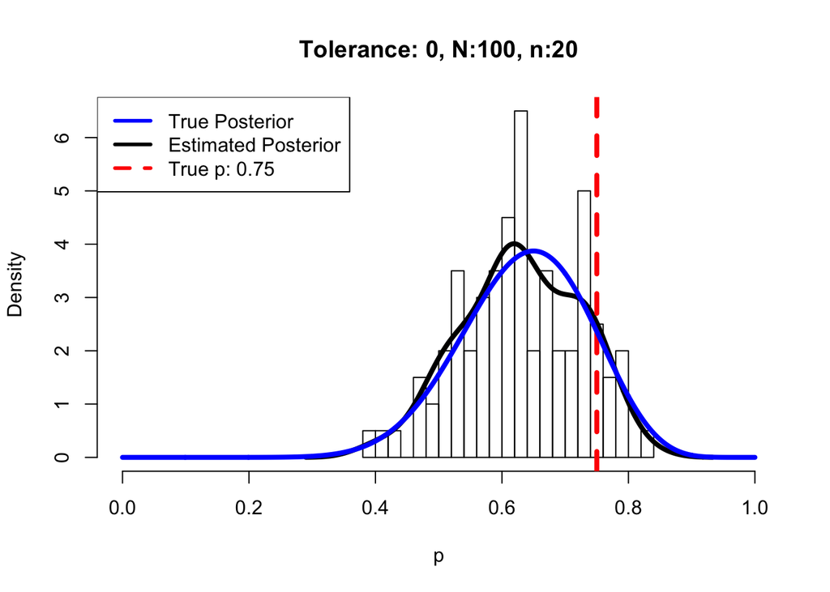

```r
grid0 <- seq(0, 1, length.out = 1000)  #define a grid
hist(p, main = paste("Tolerance: ", epsilon, ", N:", N, ", n:",n, sep = ""), nclass = 25, freq = FALSE, xlim = c(0,1))
den1 <- density(p) #computes a kernel density estimate of the ABC particles
lines(den1$x,den1$y,col = "black",lwd = 4)
abline(v = true.p, col = "red", lty = 2, lwd = 4)
lines(grid0,dbeta(grid0,sum(data)+alpha.hyper,n-sum(data)+beta.hyper),col = "blue",lwd = 4)
legend("topleft", c("True Posterior","Estimated Posterior",paste("True p: ", true.p, sep = "")), col = c("blue","black","red"), lty = c(1,1,2),lwd = 3)
```

### Exercises

Do the following:

1. The sample size, $n$, is currently set to 20. Try running the code with different values for $n$ (e.g. $n = 10, 50, 100$). What happens to the true posterior as $n$ increases? What happens as $n$ decreases?
2. Set $n=20$. The *particle* sample size, *N*, is currently set to 100. Try running the code with different values for $N$ (e.g. $N = 25, 200, 500$). What happens to the ABC posterior as $N$ increases? What happens as $N$ decreases?
3. Set $N = 200$. The tolerance, $\epsilon$, is currently set to 0. Try running the code with different values for $\epsilon$ (e.g. $\epsilon = 0.01, 0.1, 1$). What conclusions can you draw?
4. The probability, $p$, is currently set to 0.75. Try running the code with different values for $p$ (between 0 and 1 since it is a probability). What happens to the true posterior as you change this?
5. The distance function, $\rho$, is currently set to be $\rho(y,x) = |\sum_{i = 1}^n y_i - \sum_{i = 1}^nx_i|/n$. Try running the code without the absolute value in the distance function (i.e. $\rho(y,x) = (\sum_{i = 1}^n y_i - \sum_{i = 1}^nx_i)/n$). What happens to the ABC-posterior? Why does this happen? *Hint: consider the values of the means of the generated data (i.e., the generated $\hat{p} = n^{-1}\sum_{i = 1}^n x_i$) that are going to be accepted with this distance function.*

# Normal example

Consider a data set drawn from a Normal distribution with unknown mean, $\mu$, and known standard deviation, $\sigma$:

$$\begin{align*}
\mu &\sim N(\mu_0, \sigma^2_0) \nonumber \\
Y_i\mid \mu, \sigma^2 &\sim N(\mu, \sigma^2) \nonumber
\end{align*}$$

### Set the initial parameters

```r
set.seed(123)
n <- 25             #number of observations
N <- 100            #particle sample size
true.mu <- 0        #true parameter value (considered unknown)
sigma <- 1      #true parameter value (considered known)
data <- rnorm(n,true.mu,sigma)  #observations
```

### Distance function

**WARNING**: when you change the distance function, it is a good idea to start by running it with a larger epsilon

```r
rho <- function(y,x) abs(sum(y)-sum(x))/n
epsilon <- 0.05 #Tolerance
```

### Hyper parameters for prior

```r
mu.hyper <- 0               #Hyper parameter
sigma.hyper <- 10           #Hyper parameter
```

### ABC code

The basic ABC algorithm for our Normal example.

```r
mu <- numeric(N)            #"Good" proposals stored in mu
for(i in 1:N){
  d <- epsilon +1
  while(d>epsilon) {
    proposed.mu <- rnorm(1,0,sigma.hyper) #<--prior draw
    x <- rnorm(n, proposed.mu, sigma)
    d <- rho(data,x)
  }
  mu[i] <- proposed.mu
}
```

### Plot the resulting posterior

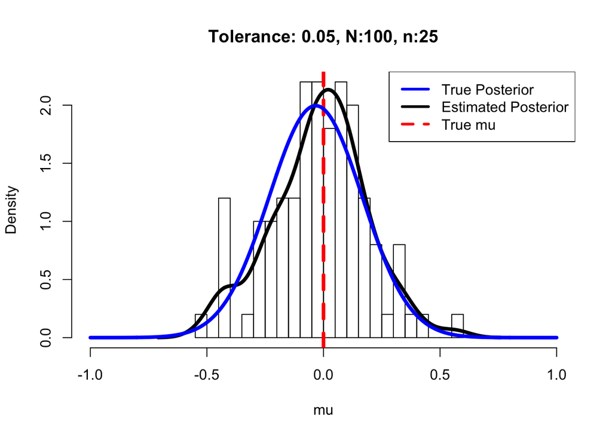

```r
grid0 <- seq(-1, 1, length.out = 1000)
mu1 <- (mu.hyper/sigma.hyper^2 + sum(data)/sigma^2)/(1/sigma.hyper^2 + n/sigma^2) #True posterior mean
sigma1 <- sqrt(1/(1/sigma.hyper^2 + n/sigma^2))  #True posterior standard deviation
hist(mu, main = paste("Tolerance: ", epsilon, ", N:", N, ", n:",n, sep = ""), nclass = 25, freq = FALSE, xlim = c(-1,1))
den1 <- density(mu)
lines(den1$x,den1$y,col = "black",lwd = 4)
abline(v = true.mu, col = "red", lty = 2, lwd = 4)
lines(grid0,dnorm(grid0,mu1,sigma1),col = "blue",lwd = 4)
legend("topright", c("True Posterior","Estimated Posterior","True mu"), col = c("blue","black","red"), lty = c(1,1,2),lwd = 3)
```

### Exercises

1. The tolerance, $\epsilon$, is currently set to 0.05. Try running the code with different values for $\epsilon$. What conclusions can you draw?
2. Set $\epsilon = 0.005$. The true value for $\mu$ is currently set at 0 and $\sigma^2$ is 1. What happens to the true posterior as you change these values?
3. The distance function, $\rho$, is currently set to be $\rho(y,x) = |\sum_{i = 1}^n y_i - \sum_{i = 1}^nx_i|/n$. Try different distance functions to see what happens (e.g. $\rho(y,x) = (\sum_{i = 1}^n y_i - \sum_{i = 1}^nx_i)^2/n$, KS distance with R function **ks.test**). What happens to the ABC-posterior? Why does this happen? How does it impact the tolerances?
4. Remove the assumption that $\sigma^2$ is known. This means you will have to (1) Determine an appropriate prior distribution on $\sigma^2$ (e.g. inverse-gamma, uniform), (2) Pick an appropriate summary statistic (*hint: find a sufficient statistic for $\sigma^2$*), (3) Set-up a 2-dimensional distance function and a 2-dimensional tolerance to account for the two summary statistics.

# Normal example - sequential

### Set the initial parameters

```r
set.seed(123)
n <- 25             #number of observations
N <- 100            #particle sample size
true.mu <- 0        #true parameter value (considered unknown)
sigma <- 1      #true parameter value (considered known)
data <- rnorm(n,true.mu,sigma)  #observations

time.steps <- 10    #Here you can change the number of time steps in the sequential algorithm
epsilon <- 1        #Starting tolerance
```

### Distance function

**WARNING**: when you change the distance function, it is a good idea to start by running it with a larger epsilon

```r
rho <- function(y,x) abs(sum(y)-sum(x))/n
```

### Hyper parameters for prior

```r
mu.hyper <- 0       #Hyper parameter
sigma.hyper <- 10       #Hyper parameter
```

### ABC-Population Monte Carlo code

ABC-PMC algorithm for our Normal example

```r
weights <- matrix(1/N,time.steps,N)
mu <- matrix(NA,time.steps,N)
d <- matrix(NA,time.steps,N)
for(t in 1:time.steps){
  print(t)
  if(t==1){
    for(i in 1:N){
      d[t,i] <- epsilon +1
      while(d[t,i]>epsilon) {
        proposed.mu <- rnorm(1,0,sigma.hyper) #<--prior draw
        x <- rnorm(n, proposed.mu, sigma)
        d[t,i] <- rho(data,x)
      }
      mu[t,i] <- proposed.mu
    }} else{
      epsilon <- c(epsilon,quantile(d[t-1,],.75))
      mean.prev <- sum(mu[t-1,]*weights[t-1,])
      var.prev <- sum((mu[t-1,] - mean.prev)^2*weights[t-1,])
      for(i in 1:N){
        d[t,i] <- epsilon[t]+1
        while(d[t,i]>epsilon[t]) {
          sample.particle <- sample(N, 1, prob = weights[t-1,])
          proposed.mu0 <- mu[t-1, sample.particle]
          proposed.mu <- rnorm(1, proposed.mu0, sqrt(2*var.prev))
          x <- matrix(rnorm(n,proposed.mu, sigma),n,1)
          d[t,i] <- rho(data,x)
        }
        mu[t,i] <- proposed.mu
        mu.weights.denominator <- sum(weights[t-1,]*dnorm(proposed.mu, mu[t-1,],sqrt(2*var.prev)))
        mu.weights.numerator <- dnorm(proposed.mu,0,sigma.hyper)
        weights[t,i] <- mu.weights.numerator/mu.weights.denominator
      }}
  weights[t,] <- weights[t,]/sum(weights[t,])
}
```

```
## [1] 1
## [1] 2
## [1] 3
## [1] 4
## [1] 5
## [1] 6
## [1] 7
## [1] 8
## [1] 9
## [1] 10
```

### Plot the resulting posterior

As before, the true posterior is known and is plotted below with a selected ABC posterior. You can change the ABC posterior by changing the value of the variable `time.step.plot.’

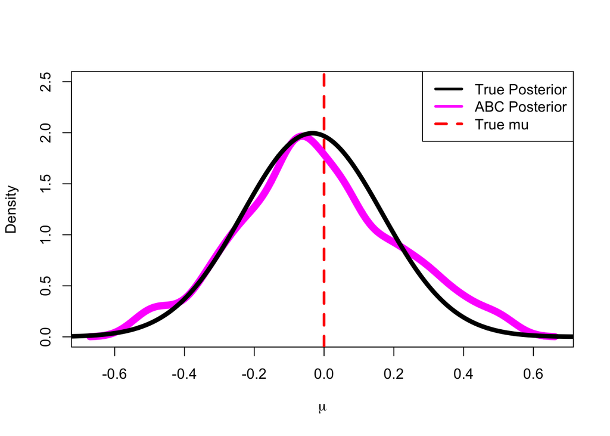

```r
col1 <- topo.colors(time.steps) #Select color for each time step
grid0 <- seq(-1, 1, length.out = 1000)
mu1 <- (mu.hyper/sigma.hyper^2 + sum(data)/sigma^2)/(1/sigma.hyper^2 + n/sigma^2)
sigma1 <- sqrt(1/(1/sigma.hyper^2 + n/sigma^2))

time.step.plot <-time.steps   #<----------------- Change the time step here to plot different ABC posteriors

den1 <- density(mu[time.step.plot,],weights = weights[time.step.plot,])
plot(den1$x,den1$y,"l", col = col1[time.step.plot],lwd = 3, xlab = expression(mu), ylab = "Density", ylim = c(0,2.5))
abline(v = true.mu, col = "red", lty = 2, lwd = 3)
den1 <- density(mu[time.step.plot,],weights = weights[time.step.plot,])
lines(den1$x,den1$y,"l", col = "magenta",lwd = 8)
lines(grid0,dnorm(grid0,mu1,sigma1),col = "black",lwd = 5)
legend("topright", c("True Posterior","ABC Posterior", "True mu"), col = c("black","magenta","red"), lty = c(1,1,2),lwd = 3)
```

### Plot all the sequential ABC posteriors

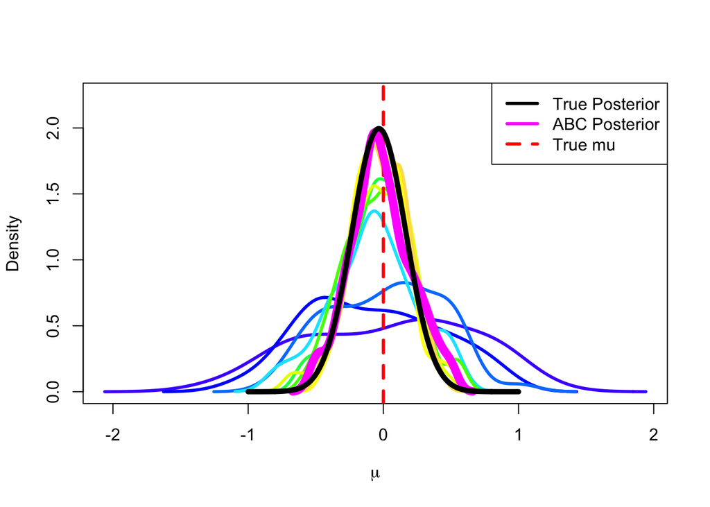

```r
grid0 <- seq(-1, 1, length.out = 1000)
den1 <- density(mu[1,],weights = weights[1,])
plot(den1$x,den1$y,"l", col = col1[1],lwd = 3, xlab = expression(mu), ylab = "Density", ylim = c(0,2.25))
for(which.t in 2:time.steps){
  den1 <- density(mu[which.t,],weights = weights[which.t,])
  lines(den1$x,den1$y,col = col1[which.t],lwd = 3)
}
abline(v = true.mu, col = "red", lty = 2, lwd = 3)
den1 <- density(mu[time.steps,],weights = weights[time.steps,])
lines(den1$x,den1$y,"l", col = "magenta",lwd = 8)
lines(grid0,dnorm(grid0,mu1,sigma1),col = "black",lwd = 5)
legend("topright", c("True Posterior","ABC Posterior", "True mu"), col = c("black","magenta","red"), lty = c(1,1,2),lwd = 3)
```

### Plots the decreasing tolerances

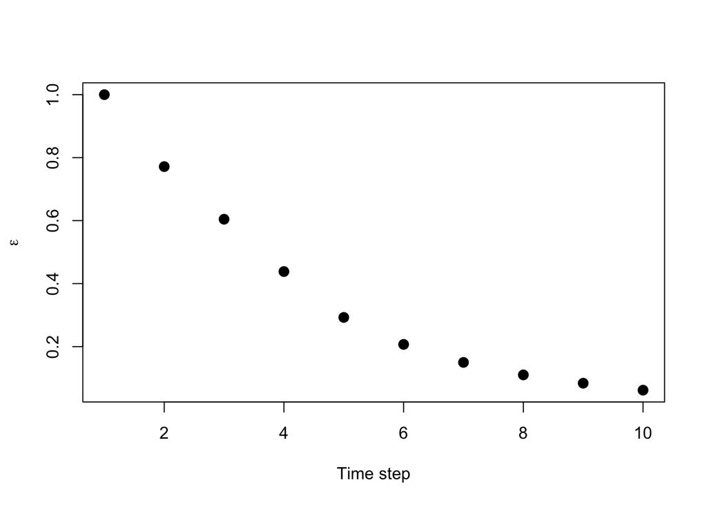

```r
plot(epsilon, pch = 19, lwd = 3, xlab = "Time step", ylab = expression(epsilon))
```

### Exercises

In this problem, we are considering the ABC - Population Monte Carlo algorithm. Do the following:

1. Run the code and plot the ABC - posteriors at different time steps. How do they compare?
2. There are currently 10 time steps in the algorithm. Trying changing this to something larger, say 20. Is there a significant improvement in the posterior at $t = 10$ versus $t = 20$? How are you deciding?
3. Remove the assumption that $\sigma^2$ is known. Use the same set-up as before, but now you have to figure out how to do it sequentially. Use the updating kernel for $\mu$ as an example for how to update $\sigma^2$.

# Photon-counting aperture photometry

Next we will go through an example developed by Tom Loredo for the earlier portion of this workshop.

### Set the initial parameters

These parameters include specification of the selection effect, which will be a threshold that has to be achieved, n_th, for a source to make it into our sample.

The total expected number of counts coming from a source is
$$\mu(F) = \epsilon F + \epsilon B + C = \epsilon F + \nu$$
where $F$ is the photon number flux of the source, $\epsilon$ is the exposure (area $\times$ time), $B$ is the background rate, and $C$ is additive contamination (and $\nu$ is the expected number of non-source photons, $\epsilon B + C$).

To guard against false detections, we can incorporate a detection threshold, $n_{th}$, so that $n > n_{th}$ in order for $n$ to join the sample.

```r
set.seed(123)
k <- 4 #k-sigma threshold for the selection effect
nu <- 9.373 # expected background contribution
n_th <- k^2*(0.5 + 0.5*sqrt(1 + 4*nu/k^2))^2
n_th
```

```
## [1] 32.00065
```

```r
expo <- (32 - nu)/0.1
```

### Define several functions

The function *ecounts* computes the expected number of counts from a source, $\mu(F) = \epsilon F + \nu$, for a given flux, $f$.

```r
#FUNCTION:  ecounts is a function that returns the expected count for a source with dimensionless flux f
ecounts <- function(f){expo*f+nu}
ecounts(10) #Example of function use
```

```
## [1] 2272.073
```

The function *f_est* computes a (dimensionless) flux estimate given some observed number of photons, $n$.

```r
#FUNCTION: Compute a (dimensionless) flux estimate, given the number of observed photons, n.
f_est <- function(n){
  out <-list()
  out$f_hat <- (n-nu)/expo
  out$sig_f <- sqrt(n)/expo
  return(out) #Returns a tuple: (f_hat, sig_f)
}
```

The function *eta* computes the detection efficiency. We will not need this for ABC, but it is included for completeness.

```r
#FUNCTION:  Detection efficiency for sources with dimensionless flux f.
#Run ?pgamma for discussion about the lower incomplete gamma function
eta <- function(f){pgamma(expo*f + nu, n_th+1, scale = 1) }
```

### Quick checks:

Setting $n$ exactly equal to its expectation should give a perfect f_hat estimate.

```r
cat('f_hat should be 1:', f_est(ecounts(1))$f_hat, ", ", f_est(ecounts(1))$sig_f,'\n')
```

```
## f_hat should be 1: 1 ,  0.06784226
```

Expected counts from a flux of 0.1*F_0 should be at threshold:

```r
cat('Expected counts at f=.1 vs. thresold:', ecounts(.1), n_th)
```

```
## Expected counts at f=.1 vs. thresold: 32 32.00065
```

### Forward model

*genData* provides a simulated dataset for a given $n$, $\alpha$, $\beta$, and $n_{th}$. If one does not want to include the selection effect, it can be removed from the *while-loop*.

R’s *rpois()* function has some issues if the *ecounts(f)* is over the machine precision; when that occurs the sample, $n$ (*nflux* in the code below) is drawn from a Normal distribution instead of the Poisson.

```r
genData <- function(n, alpha, beta, n_th){
  # n = number of sources to generate
  # alpha = power law index
  # beta = power law linear "rolling" parameter
  # n_th = selection threshold
  sig <- 1/sqrt(-beta)
  mu <- sig*(alpha + 1)
  est <- matrix(NA, nrow = n, ncol = 1)
  for(ii in 1:n){
    nflux <- 0
    while(is.na(est[ii]) | nflux < n_th){
      f <- rlnorm(1, meanlog = mu, sdlog = sig) #Flux population model
      if(ecounts(f) < (0.99*.Machine$integer.max)){
        nflux <- rpois(1, ecounts(f))   #Observed flux count (accounting for exposure and background)
      }else{
        nflux <- round(rnorm(1, ecounts(f), sqrt(ecounts(f))))
      }
      est[ii] <- f_est(nflux)$f_hat                             #Estimated flux
    }
  }
  return(est)
}
```

### Generate observations

The `real’ observations are drawn here using the input values for $alpha$ and $beta$

```r
alpha0 <- -1.5 #Fiducial index
beta0 <-  -0.25  #Roll rate
n <- 50
Yobs <- genData(n, alpha0, beta0, n_th)     #"Real" observations
```

### Distance function

This distance function is setup to compare the mean and standard deviations of the real and simulated observations. These are not necessarily the best summaries to use; try different distances and see how the ABC posterior chanes.

**WARNING**: due to how the subsequent code is set up, keep at least two summaries in the distance function. If you only want to include one, then set the second to a constant.

```r
distance.function = function(x,y, inputDist){
  d1 <- abs(mean(x) - mean(y))
  d2 <- abs(sd(x) - sd(y))
  out <- cbind(d1, d2)
  return(out)
}
```

### Set prior distributions

We are going to considered $\alpha$ a fixed, known, parameter so we will only specify a prior on $\beta$.

```r
# alphaPrior <- function(n){rcauchy(n, location = 0, scale = 1)}
betaPrior <- function(n){-rexp(n, rate = 1)}
```

### ABC algorithm parameters

In general, **Ndraws** and **T_Iter** should be larger. **Ninit** is the initial number of draws from the prior in the first time step so the first tolerance(s) can be adaptively selected. This makes it easier when changing the summary statistics/distance function. **Ninit** should be some number greater than **Ndraws**, and then the **Ndraws** with the lowest distance are retained.

```r
Ndraws <- 100       #Number of ABC particles for approximating the posterior
Ninit <- Ndraws*5
T_Iter <- 3
post.beta <- NULL           #"Good" proposals
post.weights <- NULL    #Importance weights
which.quantile <- .5        #Quantile for decreasing the tolerance sequence
ndist <- length(distance.function(rexp(n),rexp(n), inputDist)) # number of summary statistics
```

### Adaptive Start

```r
t_Iter <- 1
Dvals1 <- matrix(NA, nrow = Ninit, ncol = ndist)
# alphaProp1 <- numeric(Ninit)
betaProp1 <- numeric(Ninit)
for(i in 1:Ninit){
  betaProp1[i] <- betaPrior(1)
  Yprop <- genData(n, alpha0, betaProp1[i], n_th)
  Dvals1[i,] <- distance.function(Yobs,Yprop)
}

D0 <- rank(apply(scale(Dvals1, center = FALSE)^2,1,sum), ties.method = "random")
pickNdraws <- D0<=Ndraws
Dvals <- Dvals1[pickNdraws,]

post.beta[[t_Iter]] <- betaProp1[pickNdraws]
post.weights[[t_Iter]] <- rep(1/Ndraws, Ndraws)

post.tolSeq <- matrix(NA, nrow = T_Iter, ncol = ndist)
post.tolSeq[t_Iter, ] <- apply(Dvals, 2, max)
tolSeq <- apply(Dvals, 2, quantile, which.quantile)
cat('Original tolerance', post.tolSeq[t_Iter, ],'\n')
```

```
## Original tolerance 0.8558801 4.749386
```

```r
cat('New tolerance is', tolSeq,'\n')
```

```
## New tolerance is 0.5141645 1.152447
```

### ABC-PMC

The importance weights are a ratio of the prior distribution for $\beta$ and the proposal distribution used (based on the previous time step’s particle system). Note that the parameter space constraint ($\beta < 0$) puts a constraint on the kernel used to move the particle values (a truncated normal distribution is used).

```r
for(t_Iter in 2:T_Iter){
  print(t_Iter)
  post.beta[[t_Iter]]   <- numeric(Ndraws)
  post.weights[[t_Iter]]    <- numeric(Ndraws)
  Dvals <- matrix(NA, nrow = Ndraws, ncol = ndist)

  prev.draws <-  post.beta[[t_Iter-1]]
  prev.weights <- post.weights[[t_Iter - 1]]

  mean.prev <- sum(prev.draws*prev.weights)
  var.prev <- sum((prev.draws - mean.prev)^2*prev.weights)

  for(i in 1:Ndraws){

    jj <- 0
    while(jj == 0) {
      # Draw from the previous values
      index.samp <- sample(1:Ndraws, 1, prob = prev.weights)
      theta.gen <- prev.draws[index.samp]

      # Perturb it
      thetaProp <- rnorm(1, theta.gen, sqrt(2*var.prev))
      # Try again if beta becomes positive
      while(thetaProp > 0){
        thetaProp <- rnorm(1, theta.gen, sqrt(2*var.prev))
      }
      betaProp <- thetaProp
      Yprop <- genData(n, alpha0, betaProp, n_th)
      Dvals1 <- distance.function(Yobs,Yprop)
      if(sum(Dvals1 <= tolSeq)==ndist){jj <- jj + 1}
    }
    post.beta[[t_Iter]][i]  <- betaProp
    Dvals[i,] <- Dvals1

    wt.numerator <- dexp(-betaProp) #Betas are negative so need to flip
    trunc.norm <- pnorm(0, prev.draws, sqrt(2*var.prev)) #Used a truncated normal to "move" the particles; this is adjustment needed for density
    wt.denominator <- sum(prev.weights*dnorm(betaProp, prev.draws, sqrt(2*var.prev))/trunc.norm)
    post.weights[[t_Iter]][i] <- wt.numerator/wt.denominator
  }
  post.weights[[t_Iter]] <-   post.weights[[t_Iter]]/sum(post.weights[[t_Iter]])    ### Add weights

  post.tolSeq[t_Iter, ] <- tolSeq
  tolSeq <- apply(Dvals, 2, quantile, which.quantile)
}
```

```
## [1] 2
## [1] 3
```

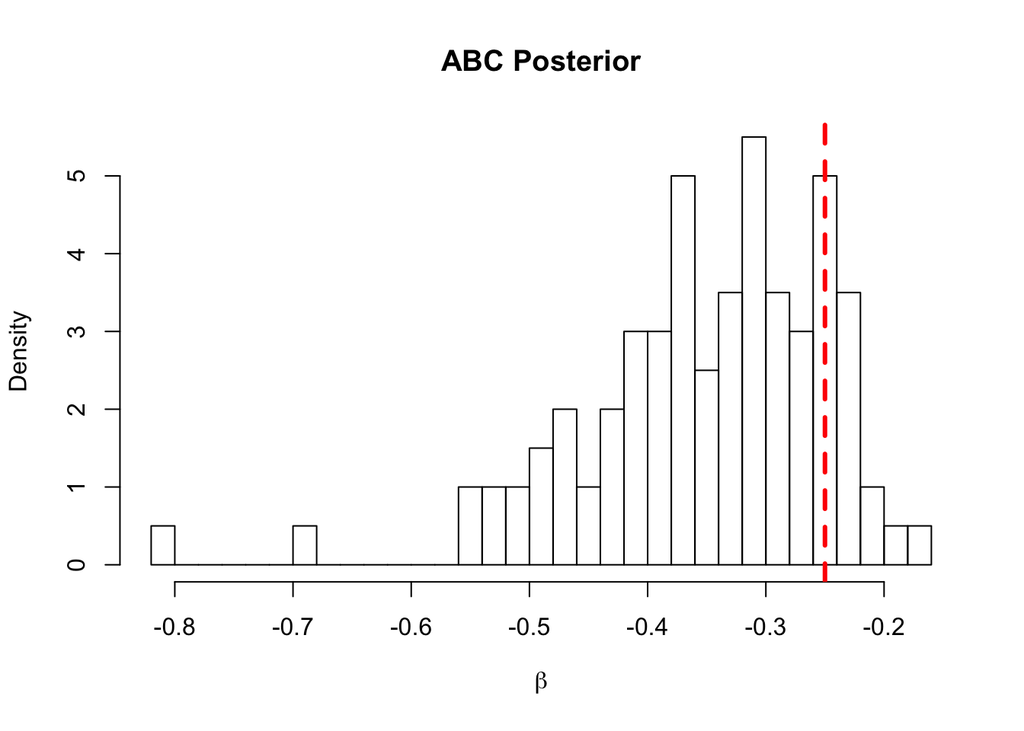

```r
t <- t_Iter
y <- post.beta[[t]]
hist(y, nclass = 25, probability = TRUE, xlab = expression(beta), main = "ABC Posterior", ylab = "Density")
abline(v = beta0, col = "red", lty = 2, lwd = 3)
```

### Exercises

1. Run the code and plot the ABC - posteriors at different time steps. How do they compare?
2. Remove the assumption that $\alpha$ is known. Be sure to update the importance weights as well!